# Pre-Linkage Data Quality: preflight(), check_medicare(), and flock()

Preparing your data before murmuration()

Dr Nicolas Smoll, SCPHU, Sunshine Coast Hospital and Health Service

2026-11-24

```r
library(starling)
library(mudnester)   # clean_the_nest() and the clutch_* datasets
library(dplyr)
library(ggplot2)

aviary_cols <- c(satin = "#325D88", chestnut = "#86251C", wattle = "#D8A31A",
                 evergreen = "#08403B", mud = "#A67D4C", slate = "#3E3F3A")
```

## (*)> Why pre-linkage quality matters

The Fellegi-Sunter EM algorithm scores pairs by comparing field values. Poor data quality in any of those fields degrades the score distribution in ways that no threshold choice can fully recover:

- **High missingness** in a comparison variable removes its contribution to the weight, so true matches drift down towards the non-match cluster.
- **Invalid Medicare numbers** that happen to resemble another person’s add spurious weight to false pairs.
- **Name variation** (nicknames, same-sound spellings, typos) is expected, but systematic encoding differences are not.
- **Inconsistent coding** of a blocking field means true pairs are never even compared.

This vignette works through all four on two of the `clutch` teaching datasets shipped in `mudnester`: the notifiable-disease linelist (`clutch_cases`, 3,182 notifications) and the Australian Immunisation Register extract (`clutch_air`, 31,200 encounter rows). Both are synthetic – no real person data – but built with the error profiles of real NoCS and AIR extracts, following the notifications + AIR design of a regional Queensland vaccine effectiveness linkage study [1]. Each record carries a `truth_id`, which real data never has; we use it here only to *measure* how much each data-quality decision costs.

## (*)> The raw extracts

```r
clutch_cases |>
  select(notification_id, condition, first_name, surname, date_of_birth, sex,
         medicare_number) |>
  head(6) |>
  knitr::kable()
```

| notification_id | condition | first_name | surname | date_of_birth | sex | medicare_number |
| --- | --- | --- | --- | --- | --- | --- |
| NOC4304827 | COVID-19 | Edward | Marshall | 1956-10-08 | M | 6592585881 |
| NOC6438426 | COVID-19 | Christine | McDonald | 1947-08-16 | F | 38484344462 |
| NOC6729326 | COVID-19 | Carol | Smith | 1946-09-07 | F | 35400173562 |
| NOC9260341 | RSV | Rohan | Gupta | 1944-03-07 | M | 5770215236 |
| NOC9677547 | RSV | Margaret | Taylor | 1928-04-08 | F | 50345225221 |
| NOC1271791 | RSV | HARPREET | Sharma | 1959-09-24 | M | NA |

```r
clutch_air |>
  select(air_id, given_name, family_name, date_of_birth, sex, medicare_card,
         medicare_irn, date_of_service, antigen) |>
  head(6) |>
  knitr::kable()
```

| air_id | given_name | family_name | date_of_birth | sex | medicare_card | medicare_irn | date_of_service | antigen |
| --- | --- | --- | --- | --- | --- | --- | --- | --- |
| AIR10010969 | KATHLEEN | WRIGHT | 1933-02-19 | F | 4790506501 | 1 | 2023-08-03 | COVID-19 |
| AIR10010969 | KATHLEEN | WRIGHT | 1933-02-19 | F | 4790506501 | 1 | 2023-08-03 | Influenza |
| AIR10010969 | KATHLEEN | WRIGHT | 1933-02-19 | F | 4790506501 | 1 | 2023-10-22 | COVID-19 |
| AIR10010969 | KATHLEEN | WRIGHT | 1933-02-19 | F | 4790506501 | 1 | 2024-05-14 | Influenza |
| AIR10010969 | KATHLEEN | WRIGHT | 1933-02-19 | F | 4790506501 | 1 | 2024-06-14 | COVID-19 |
| AIR10010969 | KATHLEEN | WRIGHT | 1933-02-19 | F | 4790506501 | 1 | 2024-12-20 | COVID-19 |

Two things are already visible: the case linelist has mixed-case names and some 11-digit Medicare numbers (IRN appended), while the AIR stores upper-case family names, the 10-digit card number, and the IRN in a column of its own.

## (*)> Cleaning both sides the same way

`mudnester::clean_the_nest()` standardises both extracts into the same schema (`lettername1`, `lettername2`, `dob`, `gender`, `medicare10`, …). About 10% of respiratory notifications have no onset date, so the specimen date stands in for them first – an event date that is `NA` would otherwise switch off the event window inside `murmuration()`. The AIR keeps the IRN in a column of its own, named with `medicare_irn` (a column called exactly `medicare_irn` is picked up automatically, with a message); on the notifications it comes from the 11th digit wherever one was recorded.

```r
cases_raw <- clutch_cases |>
  mutate(
    onset_imputed = is.na(onset_date),                  # keep a flag
    onset_date    = coalesce(onset_date, specimen_date) # fall back to the specimen date
  )

cases_clean <- clean_the_nest(
  cases_raw,
  data_type   = "cases",
  drop_eggs   = TRUE,
  id_var      = "notification_id",
  diagnosis   = "condition",
  lettername1 = "first_name",
  lettername2 = "surname",
  dob         = "date_of_birth",
  gender      = "sex",
  postcode    = "postcode",
  medicare    = "medicare_number",
  onset_date  = "onset_date",
  keep_vars   = c("truth_id", "onset_imputed")
)
```

> **(*)> One vaccine type at a time.** This vignette is about identifiers, so it pivots *every* AIR encounter into one row per person – a person frame whose `vax_date_*` columns mix COVID-19, influenza, zoster and MMR doses. That is fine for checking names, dates of birth and Medicare numbers. For a vaccine question, filter the AIR extract to that vaccine first (for example `filter(antigen == "COVID-19")`) before `clean_the_nest(lie_nest_flat = TRUE)` and `murmuration()`; otherwise the dose counts and `vaccination_status` mean “any vaccine”. `vignette("linked-cohort")` does exactly that.

```r
air_clean <- clean_the_nest(
  clutch_air,                    # all antigens: a person frame for identifier checks
  data_type     = "vaccination",
  lie_nest_flat = TRUE,          # one row per person: vax_date_1, vax_type_1, ...
  drop_eggs     = TRUE,
  id_var        = "air_id",
  lettername1   = "given_name",
  lettername2   = "family_name",
  dob           = "date_of_birth",
  gender        = "sex",
  postcode      = "postcode",
  medicare      = "medicare_card",
  medicare_irn  = "medicare_irn",  # the IRN is stored apart from the card number
  vax_type      = "antigen",
  vax_date      = "date_of_service",
  keep_vars     = "truth_id"
)

c(cases = nrow(cases_clean), air_people = nrow(air_clean))
```

```
#>      cases air_people
#>       3182      10326
```

`lie_nest_flat = TRUE` turned 31200 AIR rows into 10326 people. The 207 registration-only rows (people enrolled on the AIR with no vaccine recorded) were dropped by the default `drop_the_na_vax = TRUE`.

### How names are standardised

Names are lowercased, transliterated to ASCII, and stripped of spaces *and* punctuation, so `"O'Brien"`, `"O Brien"` and `"OBRIEN"` all agree: some source systems cannot store an apostrophe, a hyphen or a space at all, and the cleaned value has to be the same whichever system the name came through. Given names come back two ways: `lettername1` is the first given name only (the first word, then stripped), and `lettername1_full` is every given name squeezed together. Examples from the AIR:

```r
air_names <- clutch_air |>
  distinct(air_id, given_name, family_name) |>
  inner_join(air_clean |> select(air_id = id_var, lettername1, lettername1_full, lettername2),
             by = "air_id")

bind_rows(
  air_names |> filter(grepl(" ", trimws(given_name)))  |> head(3),  # compound given names
  air_names |> filter(grepl(" ", trimws(family_name))) |> head(2),  # spaced family names
  air_names |> filter(grepl("[-']", family_name))      |> head(3)   # hyphens, apostrophes
) |>
  select(-air_id) |>
  knitr::kable(caption = "Raw and cleaned AIR names")
```

Raw and cleaned AIR names

| given_name | family_name | lettername1 | lettername1_full | lettername2 |
| --- | --- | --- | --- | --- |
| ZHI WEI | LIU | zhi | zhiwei | liu |
| LI NA | WANG | li | lina | wang |
| ZHI WEI | CHEN | zhi | zhiwei | chen |
| NATALIE | VAN DER BERG | natalie | natalie | vanderberg |
| WENDY | VAN DER BERG | wendy | wendy | vanderberg |
| CAITLIN | O’BRIEN | caitlin | caitlin | obrien |
| ROBERT | O’NEILL | robert | robert | oneill |
| NATALIE | O’NEILL | natalie | natalie | oneill |

For the same person, how often does each cleaned field agree exactly between the notification and the AIR?

```r
# each notification next to the same person's AIR record (truth_id: measurement only)
same_person <- cases_clean |>
  inner_join(air_clean, by = "truth_id", suffix = c("_case", "_air"))

name_agreement <- same_person |>
  summarise(
    l1      = mean(lettername1_case == lettername1_air, na.rm = TRUE),
    l1_full = mean(lettername1_full_case == lettername1_full_air, na.rm = TRUE),
    l2      = mean(lettername2_case == lettername2_air, na.rm = TRUE)
  )
name_agreement <- tibble(
  field     = c("lettername1 (first given name)",
                "lettername1_full (all given names)",
                "lettername2 (family name)"),
  agree_pct = round(100 * c(name_agreement$l1, name_agreement$l1_full,
                            name_agreement$l2), 1)
)
knitr::kable(name_agreement,
             caption = "Same person, notification vs AIR: % of cleaned names agreeing exactly")
```

Same person, notification vs AIR: % of cleaned names agreeing exactly

| field | agree_pct |
| --- | --- |
| lettername1 (first given name) | 91.0 |
| lettername1_full (all given names) | 91.0 |
| lettername2 (family name) | 95.3 |

On notifications the two given-name fields agree about equally often (91% and 91%): where a given name is compound, both sources usually record all of it. The first-name rule earns its place where one source records middle names and the other does not – a flight manifest copies the passport, for instance (see `vignette("clean-the-nest", package = "mudnester")`). Compare on `lettername1_full` instead where compound given names are the norm, or use it for a second pass. Exact disagreement is not the end of a pair either: `murmuration()` scores names by string similarity, so a dropped letter still earns most of the weight.

## (*)> `preflight()` – structured pre-linkage audit

`preflight()` runs a battery of checks across both datasets and returns a structured report. It is the recommended first step before any linkage call.

```r
audit <- preflight(
  data1        = cases_clean,
  data2        = air_clean,
  linkage_vars = c("lettername1", "lettername2", "dob", "medicare10"),
  id_col1      = "id_var",
  id_col2      = "id_var",
  date_cols    = c("dob", "onset_date"),
  medicare_col = "medicare10",
  verbose      = FALSE
)

knitr::kable(audit$completeness, digits = 1,
             caption = "Completeness of the linkage variables")
```

Completeness of the linkage variables

| variable | dataset | n_records | n_present | n_missing | pct_missing |
| --- | --- | --- | --- | --- | --- |
| lettername1 | data1 | 3182 | 3171 | 11 | 0.3% |
| lettername2 | data1 | 3182 | 3182 | 0 | 0% |
| dob | data1 | 3182 | 3179 | 3 | 0.1% |
| medicare10 | data1 | 3182 | 2691 | 491 | 15.4% |
| lettername1 | data2 | 10326 | 10326 | 0 | 0% |
| lettername2 | data2 | 10326 | 10326 | 0 | 0% |
| dob | data2 | 10326 | 10326 | 0 | 0% |
| medicare10 | data2 | 10326 | 10221 | 105 | 1% |

```r
knitr::kable(audit$duplicates, digits = 1,
             caption = "Identifier uniqueness")
```

Identifier uniqueness

| dataset | n_records | n_unique_ids | n_duplicate_ids | pct_duplicate |
| --- | --- | --- | --- | --- |
| data1 | 3182 | 3182 | 0 | 0% |
| data2 | 10326 | 10326 | 0 | 0% |

```r
audit$flags
```

```
#> [1] "[FUTURE DATE] 'dob' in data1: 2 future date(s)"
#> [2] "[MEDICARE] 113 failed checksum in data1"
```

Medicare is missing for 15% of notifications – the single largest gap and, with reissued cards (below), the reason true matches split into separate clusters of linkage weight (see `vignette("threshold-selection")`). Gaps and errors on this scale are normal: a regional infant immunisation coverage study had to resolve identifier and date-of-birth errors in about one birth-register record in ten [2].

## (*)> `check_medicare()` – Modulus 10 checksum validation

Australian Medicare numbers contain a check digit at position 9, calculated from positions 1–8 using the weights 1, 3, 7, 9, 1, 3, 7, 9. `check_medicare()` verifies this and returns a three-state flag:

| Value | Meaning |
| --- | --- |
| `1L` | Checksum passes – number is internally consistent |
| `0L` | Checksum fails – at least one digit is wrong |
| `NA` | Missing, blank, or non-numeric – not verifiable |

```r
cases_checked <- cases_clean |>
  check_medicare(medicare_col = "medicare10", output_col = "medicare_valid",
                 verbose = FALSE)
air_checked <- air_clean |>
  check_medicare(medicare_col = "medicare10", output_col = "medicare_valid",
                 verbose = FALSE)

medicare_summary <- bind_rows(
  cases_checked |> transmute(dataset = "clutch_cases", medicare_valid),
  air_checked   |> transmute(dataset = "clutch_air",   medicare_valid)
) |>
  mutate(status = case_when(medicare_valid %in% 1L ~ "Valid",
                            medicare_valid %in% 0L ~ "Fails checksum",
                            TRUE                   ~ "Missing")) |>
  count(dataset, status) |>
  group_by(dataset) |>
  mutate(pct = round(100 * n / sum(n), 1)) |>
  ungroup()

knitr::kable(medicare_summary)
```

| dataset | status | n | pct |
| --- | --- | --- | --- |
| clutch_air | Missing | 105 | 1.0 |
| clutch_air | Valid | 10221 | 99.0 |
| clutch_cases | Fails checksum | 113 | 3.6 |
| clutch_cases | Missing | 491 | 15.4 |
| clutch_cases | Valid | 2578 | 81.0 |

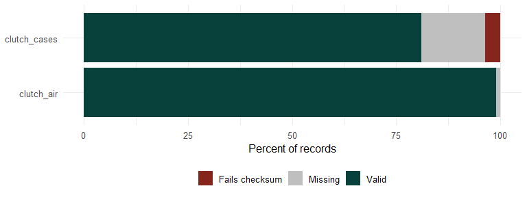

```r
ggplot(medicare_summary, aes(x = pct, y = dataset, fill = status)) +
  geom_col() +
  scale_fill_manual(values = c("Valid" = aviary_cols[["evergreen"]],
                               "Fails checksum" = aviary_cols[["chestnut"]],
                               "Missing" = "grey75")) +
  labs(x = "Percent of records", y = NULL, fill = NULL) +
  theme_minimal(base_size = 12) +
  theme(legend.position = "bottom")
```

`clean_the_nest()` already records a logical `medicare_valid`; `check_medicare()` replaces it with the three-state integer above, which keeps “missing” distinct from “wrong”.

### What to do with invalid Medicare numbers

Do not discard the record – it may still link correctly on name and date of birth. Replace the invalid number with `NA` so it contributes nothing, rather than adding misleading partial agreement:

```r
cases_checked <- cases_checked |>
  mutate(medicare10 = if_else(medicare_valid %in% 0L, NA_character_, medicare10))
air_checked <- air_checked |>
  mutate(medicare10 = if_else(medicare_valid %in% 0L, NA_character_, medicare10))
```

### Households share a card; the IRN tells them apart

Households share a Medicare card: everyone on it has the same 10 digits and differs only by the IRN (individual reference number), the 11th digit. In the AIR extract:

```r
air_checked |>
  filter(!is.na(medicare10)) |>
  count(medicare10, name = "people_on_card") |>   # people per card...
  count(people_on_card, name = "n_cards") |>       # ...and cards of each size
  knitr::kable(caption = "AIR people sharing a 10-digit Medicare number")
```

AIR people sharing a 10-digit Medicare number

| people_on_card | n_cards |
| --- | --- |
| 1 | 2695 |
| 2 | 1994 |
| 3 | 533 |
| 4 | 319 |
| 5 | 123 |
| 6 | 8 |

A comparison that rewards Medicare agreement will therefore score parents, partners and children of the true person highly. That is why Medicare is a *comparison* variable alongside names and date of birth, never a blocking variable or a deterministic key on its own.

`clean_the_nest()` returns the IRN as `medicare_irn` and the person’s own number as `medicare11` (`medicare10` followed by the IRN): household members share `medicare10` but never `medicare11`. The catch is how often each source records the IRN:

```r
detail_levels <- c("Card number + IRN", "Card number only", "No valid number")

medicare_detail <- bind_rows(
  cases_checked |> transmute(dataset = "clutch_cases", medicare10, medicare_irn),
  air_checked   |> transmute(dataset = "clutch_air",   medicare10, medicare_irn)
) |>
  mutate(detail = case_when(!is.na(medicare10) & !is.na(medicare_irn) ~ detail_levels[1],
                            !is.na(medicare10)                        ~ detail_levels[2],
                            TRUE                                      ~ detail_levels[3]),
         detail = factor(detail, levels = rev(detail_levels))) |>
  count(dataset, detail, .drop = FALSE) |>
  group_by(dataset) |>
  mutate(pct = round(100 * n / sum(n), 1)) |>
  ungroup() |>
  arrange(desc(dataset), desc(detail))

pct_cases_with_irn <- medicare_detail |>
  filter(dataset == "clutch_cases", detail == "Card number + IRN") |>
  pull(pct)

knitr::kable(medicare_detail, caption = "How much of the Medicare number each source records")
```

How much of the Medicare number each source records

| dataset | detail | n | pct |
| --- | --- | --- | --- |
| clutch_cases | Card number + IRN | 662 | 20.8 |
| clutch_cases | Card number only | 1916 | 60.2 |
| clutch_cases | No valid number | 604 | 19.0 |
| clutch_air | Card number + IRN | 10221 | 99.0 |
| clutch_air | Card number only | 0 | 0.0 |
| clutch_air | No valid number | 105 | 1.0 |

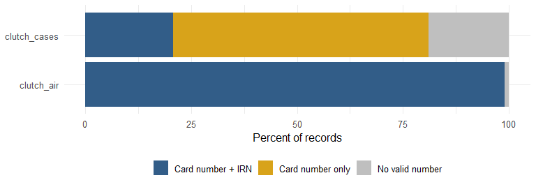

Medicare detail recorded, by source. Invalid numbers have already been set to NA.

```r
ggplot(medicare_detail, aes(x = pct, y = dataset, fill = detail)) +
  geom_col() +
  scale_fill_manual(values = c("Card number + IRN" = aviary_cols[["satin"]],
                               "Card number only"  = aviary_cols[["wattle"]],
                               "No valid number"   = "grey75"),
                    breaks = detail_levels) +
  labs(x = "Percent of records", y = NULL, fill = NULL) +
  theme_minimal(base_size = 12) +
  theme(legend.position = "bottom")
```

Where both sides do record it, the IRN separates the person from the rest of the household. Every notification with an IRN, paired with every AIR person on the same 10-digit card:

```r
cases_with_irn <- cases_checked |>
  filter(!is.na(medicare10), !is.na(medicare_irn)) |>
  select(medicare10, medicare_irn, truth_id)
air_with_irn <- air_checked |>
  filter(!is.na(medicare10), !is.na(medicare_irn)) |>
  select(medicare10, medicare_irn, truth_id)

cases_with_irn |>
  inner_join(air_with_irn, by = "medicare10", suffix = c("_case", "_air"),
             relationship = "many-to-many") |>
  mutate(irn    = if_else(medicare_irn_case == medicare_irn_air, "IRN agrees", "IRN differs"),
         person = if_else(truth_id_case == truth_id_air, "Same person", "Different person")) |>
  count(irn, person, name = "pairs") |>
  knitr::kable(caption = "Notification-AIR pairs on the same card, IRN recorded on both")
```

Notification-AIR pairs on the same card, IRN recorded on both

| irn | person | pairs |
| --- | --- | --- |
| IRN agrees | Same person | 457 |
| IRN differs | Different person | 721 |

The AIR records the IRN for almost everyone, but only 20.8% of notifications carry it – those where all 11 digits were entered. That makes the IRN a decisive *review check* rather than a routine comparison variable: a candidate pair that agrees on `medicare10` but not on the IRN is a different person on the same card, and `vignette("threshold-selection")` uses it exactly that way. Scoring `medicare11` alongside `medicare10` would count the same card twice whenever both agree, which the Fellegi-Sunter model, assuming its fields are independent, cannot allow for.

### `medicare09` or `medicare10`?

`clean_the_nest()` splits the number into the account (`medicare08`), the account plus check digit (`medicare09`) and the full card number (`medicare10`). The tenth digit is the card *issue*: it changes every time a card is replaced. Comparing the same person’s number across the two sources shows what that costs:

```r
medicare_agreement <- same_person |>
  filter(!is.na(medicare10_case), !is.na(medicare10_air)) |>
  summarise(m08 = mean(medicare08_case == medicare08_air),
            m09 = mean(medicare09_case == medicare09_air),
            m10 = mean(medicare10_case == medicare10_air))
medicare_agreement <- tibble(
  field = c("medicare08 (account)",
            "medicare09 (account + check digit)",
            "medicare10 (+ card issue digit)"),
  agree_pct = round(100 * c(medicare_agreement$m08, medicare_agreement$m09,
                            medicare_agreement$m10), 1)
)
knitr::kable(medicare_agreement,
             caption = "Same person, both sources recorded a number: % agreeing")
```

Same person, both sources recorded a number: % agreeing

| field | agree_pct |
| --- | --- |
| medicare08 (account) | 95.7 |
| medicare09 (account + check digit) | 95.7 |
| medicare10 (+ card issue digit) | 78.0 |

Using `medicare10` as a comparison variable therefore penalises everyone whose card was reissued between the two records – about 18 in every hundred pairs here. `medicare09` keeps everything that identifies the account (household members still share it) without that penalty, and is the better comparison variable in new work. The other starling vignettes keep `medicare10` so their weights line up with the package’s own examples; `vignette("threshold-selection")` measures what switching to `medicare09` does to recall at the default threshold.

## (*)> Inconsistent coding silently breaks blocking

`clutch_hospital` codes sex as `"Male"`/`"Female"`; every other source uses `"M"`/`"F"`. A blocking key built from `gender` therefore never agrees across the two sources, and the true pairs are never compared:

```r
clutch_hospital |> count(sex)
```

```
#>      sex    n
#> 1 Female 2281
#> 2   Male 1920
```

```r
clutch_air      |> count(sex)
```

```
#>   sex     n
#> 1   F 15876
#> 2   M 15324
```

```r
air_blocks <- clutch_air |>
  distinct(block = paste(sex, format(date_of_birth, "%Y")))

clutch_hospital |>
  distinct(block = paste(sex, format(birth_date, "%Y"))) |>
  semi_join(air_blocks, by = "block") |>
  nrow()   # zero: no hospital record would ever meet an AIR record
```

```
#> [1] 0
```

Harmonise first, then build blocks:

```r
hosp_raw <- clutch_hospital |>
  mutate(sex = case_when(sex == "Male"   ~ "M",
                         sex == "Female" ~ "F"))

hosp_raw |>
  distinct(block = paste(sex, format(birth_date, "%Y"))) |>
  semi_join(air_blocks, by = "block") |>
  nrow()
```

```
#> [1] 205
```

## (*)> `flock()` – blocking variable construction

`flock()` creates up to three blocking keys. `murmuration()` only compares pairs that share a key, so the choice trades computation against the chance that a true pair is split across blocks.

```r
cases_blocked <- cases_checked |>
  flock(block1_vars    = "gender",
        block2_vars    = c("gender", "birth_year"),
        block3_vars    = "postcode",
        birth_year_col = "dob")
air_blocked <- air_checked |>
  flock(block1_vars    = "gender",
        block2_vars    = c("gender", "birth_year"),
        block3_vars    = "postcode",
        birth_year_col = "dob")
```

Because the clutch carries a ground-truth identifier, we can measure two things for each key before running any linkage: how many candidate pairs it generates, and what share of true pairs land in the same block (blocking recall). Written out key by key:

```r
# candidate pairs = sum over shared keys of (records with the key) x (records with the key)
pairs_block1 <- cases_blocked |>
  filter(!is.na(block1)) |>
  count(block1, name = "n_x") |>
  inner_join(air_blocked |> count(block1, name = "n_y"), by = "block1") |>
  summarise(pairs = sum(as.numeric(n_x) * n_y)) |>
  pull(pairs)

pairs_block2 <- cases_blocked |>
  filter(!is.na(block2)) |>
  count(block2, name = "n_x") |>
  inner_join(air_blocked |> count(block2, name = "n_y"), by = "block2") |>
  summarise(pairs = sum(as.numeric(n_x) * n_y)) |>
  pull(pairs)

pairs_block3 <- cases_blocked |>
  filter(!is.na(block3)) |>
  count(block3, name = "n_x") |>
  inner_join(air_blocked |> count(block3, name = "n_y"), by = "block3") |>
  summarise(pairs = sum(as.numeric(n_x) * n_y)) |>
  pull(pairs)

# blocking recall: the share of true pairs that land in the same block
recall <- cases_blocked |>
  select(truth_id, x1 = block1, x2 = block2, x3 = block3) |>
  inner_join(air_blocked |> select(truth_id, y1 = block1, y2 = block2, y3 = block3),
             by = "truth_id") |>
  summarise(block1 = mean(x1 == y1, na.rm = TRUE),
            block2 = mean(x2 == y2, na.rm = TRUE),
            block3 = mean((x3 == y3) %in% TRUE))   # a missing postcode never matches

blocking_table <- tibble(
  block           = c("block1: gender", "block2: gender + birth year", "block3: postcode"),
  candidate_pairs = c(pairs_block1, pairs_block2, pairs_block3),
  blocking_recall = round(100 * c(recall$block1, recall$block2, recall$block3), 1)
)
knitr::kable(blocking_table, format.args = list(big.mark = ","))
```

| block | candidate_pairs | blocking_recall |
| --- | --- | --- |
| block1: gender | 16,281,188 | 99.1 |
| block2: gender + birth year | 182,240 | 97.7 |
| block3: postcode | 2,228,368 | 92.6 |

Gender alone keeps nearly every true pair together but asks for 16.3 million comparisons. Gender + birth year is around 89 times cheaper and still keeps 97.7% of true pairs together. The pairs it loses have either a birth year that differs between sources (off by one, or a decade slip such as `1958` keyed as `1968`) or a sex recorded differently (including `"U"`, unknown, on the notification). Postcode loses everyone who moved house between the two records, and every notification with no postcode.

### Phonetic blocking

A Soundex code of the surname is immune to birth-year errors and to many spelling variants (`Smith`/`Smyth`, `McDonald`/`MacDonald`, `Reid`/`Reed`), so it recovers a different set of true pairs:

```r
# block1: Soundex(surname) + gender; block2: gender + birth year, for comparison
cases_phon <- cases_checked |>
  flock(block1_vars     = c("lettername2_soundex", "gender"),
        block2_vars     = c("gender", "birth_year"),
        phonetic_vars   = "lettername2",
        phonetic_method = "soundex",
        birth_year_col  = "dob")
air_phon <- air_checked |>
  flock(block1_vars     = c("lettername2_soundex", "gender"),
        block2_vars     = c("gender", "birth_year"),
        phonetic_vars   = "lettername2",
        phonetic_method = "soundex",
        birth_year_col  = "dob")

cases_phon |>
  distinct(lettername2, lettername2_soundex) |>
  head(8) |>
  knitr::kable()
```

| lettername2 | lettername2_soundex |
| --- | --- |
| marshall | M624 |
| mcdonald | M235 |
| smith | S530 |
| gupta | G130 |
| taylor | T460 |
| sharma | S650 |
| kding | K352 |
| rossi | R200 |

```r
pairs_soundex <- cases_phon |>
  filter(!is.na(block1)) |>
  count(block1, name = "n_x") |>
  inner_join(air_phon |> count(block1, name = "n_y"), by = "block1") |>
  summarise(pairs = sum(as.numeric(n_x) * n_y)) |>
  pull(pairs)

phonetic_recall <- cases_phon |>
  select(truth_id, sdx_x = block1, year_x = block2) |>
  inner_join(air_phon |> select(truth_id, sdx_y = block1, year_y = block2),
             by = "truth_id") |>
  mutate(same_soundex   = sdx_x == sdx_y,
         same_birthyear = year_x == year_y) |>
  summarise(year   = mean(same_birthyear, na.rm = TRUE),
            sdx    = mean(same_soundex, na.rm = TRUE),
            either = mean(same_birthyear | same_soundex, na.rm = TRUE))

tibble(
  strategy        = c("gender + birth year", "Soundex(surname) + gender",
                      "either (two passes, union)"),
  candidate_pairs = c(pairs_block2, pairs_soundex, pairs_block2 + pairs_soundex),
  blocking_recall = round(100 * c(phonetic_recall$year, phonetic_recall$sdx,
                                  phonetic_recall$either), 1)
) |>
  knitr::kable(format.args = list(big.mark = ","))
```

| strategy | candidate_pairs | blocking_recall |
| --- | --- | --- |
| gender + birth year | 182,240 | 97.7 |
| Soundex(surname) + gender | 293,864 | 97.1 |
| either (two passes, union) | 476,104 | 99.0 |

Neither single key reaches the combined recall: each loses a different kind of error. This is the case for **multi-pass blocking** – run `murmuration()` once per key and keep the best-scoring link per record:

```r
# For a vaccine question, the AIR side holds ONE vaccine type (see the callout above)
air_covid_phon <- clutch_air |>
  filter(antigen == "COVID-19") |>
  clean_the_nest(data_type = "vaccination", lie_nest_flat = TRUE, ...) |>
  check_medicare() |>
  flock(block1_vars     = c("lettername2_soundex", "gender"),
        block2_vars     = c("gender", "birth_year"),
        phonetic_vars   = "lettername2",
        phonetic_method = "soundex",
        birth_year_col  = "dob")

# pass 1: block on gender + birth year
linked_year <- murmuration(
  data_x          = cases_phon,
  data_y          = air_covid_phon,
  linkage_type    = "cohort2event",
  event_type      = "vaccination",
  event_date      = "onset_date",
  id_var          = "id_var",
  blocking_var    = "block2",             # gender + birth year
  compare_vars    = c("lettername1", "lettername2", "dob", "medicare10"),
  threshold_value = 8
)

# pass 2: block on Soundex(surname) + gender
linked_sdx <- murmuration(
  data_x          = cases_phon,
  data_y          = air_covid_phon,
  linkage_type    = "cohort2event",
  event_type      = "vaccination",
  event_date      = "onset_date",
  id_var          = "id_var",
  blocking_var    = "block1",             # Soundex(surname) + gender
  compare_vars    = c("lettername1", "lettername2", "dob", "medicare10"),
  threshold_value = 8
)

# keep the best-scoring link per case across both passes
linked_all <- bind_rows(linked_year, linked_sdx) |>
  arrange(desc(threshold), desc(weights)) |>
  distinct(id_var, .keep_all = TRUE)
```

### Choosing blocking variables for Australian datasets

| Dataset size | Recommended block | Rationale |
| --- | --- | --- |
| < 10 000 records | `gender` | Broadest; halves candidate space immediately |
| 10 000–500 000 | `gender` + `birth_year` composite | Balances sensitivity and specificity |
| > 500 000 | `postcode` + `birth_year` | Fine-grained; requires high postcode completeness |
| Names captured verbally (contact tracing) | Soundex/Metaphone of surname + `gender`, as a second pass | Tolerates spelling variation and date-of-birth errors |

## (*)> Putting it together

```r
library(starling)
library(mudnester)
library(dplyr)

# 1. Clean both sources the same way (impute missing onset dates first)
cases <- clutch_cases |>
  mutate(onset_date = coalesce(onset_date, specimen_date)) |>
  clean_the_nest(data_type = "cases", id_var = "notification_id", ...)

# ... and the AIR for ONE vaccine type
air <- clutch_air |>
  filter(antigen == "COVID-19") |>
  clean_the_nest(data_type = "vaccination", lie_nest_flat = TRUE,
                 medicare = "medicare_card", medicare_irn = "medicare_irn", ...)

# 2. Audit
preflight(cases, air,
          linkage_vars = c("lettername1", "lettername2", "dob", "medicare10"),
          medicare_col = "medicare10")

# 3. Medicare: invalid numbers become NA; 4. Blocks (harmonise coding first)
cases <- cases |>
  check_medicare() |>
  mutate(medicare10 = if_else(medicare_valid %in% 0L, NA_character_, medicare10)) |>
  flock(block1_vars = c("gender", "birth_year"), birth_year_col = "dob")
air <- air |>
  check_medicare() |>
  mutate(medicare10 = if_else(medicare_valid %in% 0L, NA_character_, medicare10)) |>
  flock(block1_vars = c("gender", "birth_year"), birth_year_col = "dob")

# 5. Link -- see vignette("linked-cohort")
```

## (*)> References

1. Smoll NR, Al Imam MH, Shulz C, Booy R, Khandaker G. The effectiveness of vaccination for preventing hospitalisation with COVID-19 in regional Queensland: a data linkage study. Med J Aust. 2023;219(4):162–165. doi:10.5694/mja2.52019. **Precedent**: the linkage key (first name, last name, date of birth) and the notifications/admissions/AIR design these datasets mirror.
2. Roughan WH, Cavanagh-Ochiai B, Barnekow D, Lottkowitz K, Schafer K, Camadoo L, Smoll NR. Infant respiratory syncytial virus (RSV) immunisation coverage in an Australian regional area, 1 May 2024 – 31 October 2025. Commun Dis Intell. 2026;50. doi:10.33321/cdi.2026.50.031. **Precedent**: about 10% of that study’s birth-register records carried identifier or date-of-birth errors, resolved with weighted-score matching; the clutch error rates are of the same order.